# Ch7_Environment_2

Min-Yao

2022-10-21

```r
library(rlang)
```

## 7.4 Special environments

Most environments are not created by you (e.g. with `env()`) but are instead created by R. In this section, you’ll learn about the most important environments, starting with the package environments. You’ll then learn about the function environment bound to the function when it is created, and the (usually) ephemeral execution environment created every time the function is called. Finally, you’ll see how the package and function environments interact to support namespaces, which ensure that a package always behaves the same way, regardless of what other packages the user has loaded.

### 7.4.1 Package environments and the search path

Each package attached by `library()` or `require()` becomes one of the parents of the global environment. The immediate parent of the global environment is the last package you attached[^1], the parent of that package is the second to last package you attached, …

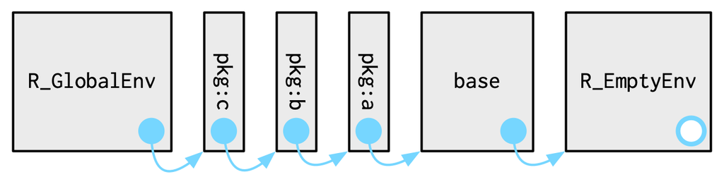

If you follow all the parents back, you see the order in which every package has been attached. This is known as the **search path** because all objects in these environments can be found from the top-level interactive workspace. You can see the names of these environments with `base::search()`, or the environments themselves with `rlang::search_envs()`:

```r
library(rlang)
```

```r
search()
```

```
##  [1] ".GlobalEnv"        "package:rlang"     "package:stats"
##  [4] "package:graphics"  "package:grDevices" "package:utils"
##  [7] "package:datasets"  "package:methods"   "Autoloads"
## [10] "package:base"
```

```r
search_envs()
```

```
##  [[1]] $ <env: global>
##  [[2]] $ <env: package:rlang>
##  [[3]] $ <env: package:stats>
##  [[4]] $ <env: package:graphics>
##  [[5]] $ <env: package:grDevices>
##  [[6]] $ <env: package:utils>
##  [[7]] $ <env: package:datasets>
##  [[8]] $ <env: package:methods>
##  [[9]] $ <env: Autoloads>
## [[10]] $ <env: package:base>
```

The last two environments on the search path are always the same:

- The `Autoloads` environment uses delayed bindings to save memory by only loading package objects (like big datasets) when needed.
- The base environment, `package:base` or sometimes just `base`, is the environment of the base package. It is special because it has to be able to bootstrap the loading of all other packages. You can access it directly with `base_env()`.

Note that when you attach another package with `library()`, the parent environment of the global environment changes:

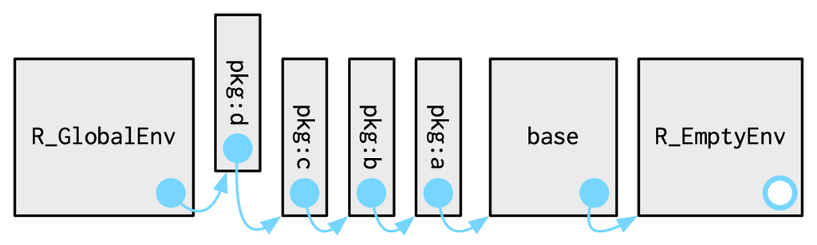

### 7.4.2 The function environment

A function binds the current environment when it is created. This is called the **function environment**, and is used for lexical scoping. Across computer languages, functions that capture (or enclose) their environments are called **closures**, which is why this term is often used interchangeably with *function* in R’s documentation.

You can get the function environment with `fn_env()`:

```r
y <- 1
f <- function(x) x + y
fn_env(f)
```

```
## <environment: R_GlobalEnv>
```

Use `environment(f)` to access the environment of function `f`.

In diagrams, I’ll draw a function as a rectangle with a rounded end that binds an environment.

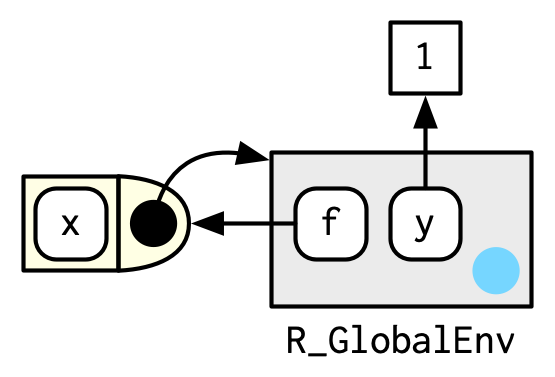

In this case, `f()` binds the environment that binds the name `f` to the function. But that’s not always the case: in the following example `g` is bound in a new environment `e`, but `g()` binds the global environment. The distinction between binding and being bound by is subtle but important; the difference is how we find `g` versus how `g` finds its variables.

```r
e <- env()
e$g <- function() 1
```

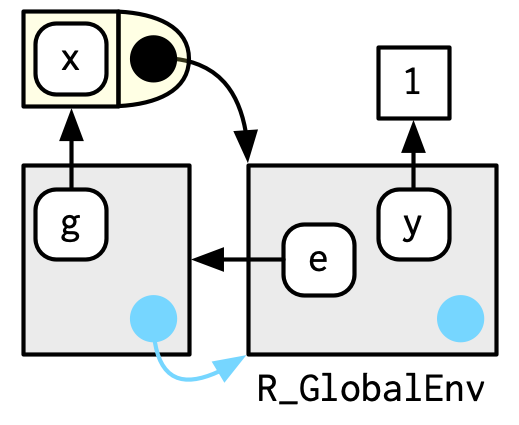

### 7.4.3 Namespaces

In the diagram above, you saw that the parent environment of a package varies based on what other packages have been loaded. This seems worrying: doesn’t that mean that the package will find different functions if packages are loaded in a different order? The goal of **namespaces** is to make sure that this does not happen, and that every package works the same way regardless of what packages are attached by the user.

For example, take `sd()`:

```r
sd
```

```
## function (x, na.rm = FALSE)
## sqrt(var(if (is.vector(x) || is.factor(x)) x else as.double(x),
##     na.rm = na.rm))
## <bytecode: 0x000002044d61da88>
## <environment: namespace:stats>
```

`sd()` is defined in terms of `var()`, so you might worry that the result of `sd()` would be affected by any function called `var()` either in the global environment, or in one of the other attached packages. R avoids this problem by taking advantage of the function versus binding environment described above. Every function in a package is associated with a pair of environments: the package environment, which you learned about earlier, and the **namespace** environment.

- The package environment is the external interface to the package. It’s how you, the R user, find a function in an attached package or with `::`. Its parent is determined by search path, i.e. the order in which packages have been attached.
- The namespace environment is the internal interface to the package. The package environment controls how we find the function; the namespace controls how the function finds its variables.

Every binding in the package environment is also found in the namespace environment; this ensures every function can use every other function in the package. But some bindings only occur in the namespace environment. These are known as internal or non-exported objects, which make it possible to hide internal implementation details from the user.

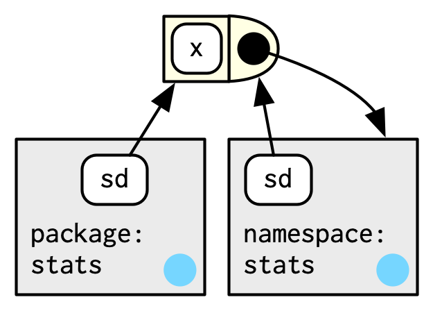

Every namespace environment has the same set of ancestors:

- Each namespace has an **imports** environment that contains bindings to all the functions used by the package. The imports environment is controlled by the package developer with the `NAMESPACE` file.
- Explicitly importing every base function would be tiresome, so the parent of the imports environment is the base **namespace**. The base namespace contains the same bindings as the base environment, but it has a different parent.
- The parent of the base namespace is the global environment. This means that if a binding isn’t defined in the imports environment the package will look for it in the usual way. This is usually a bad idea (because it makes code depend on other loaded packages), so `R CMD check` automatically warns about such code. It is needed primarily for historical reasons, particularly due to how S3 method dispatch works.

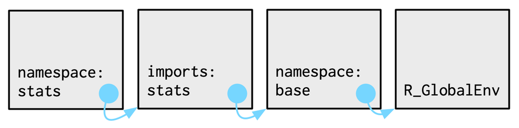

Putting all these diagrams together we get:

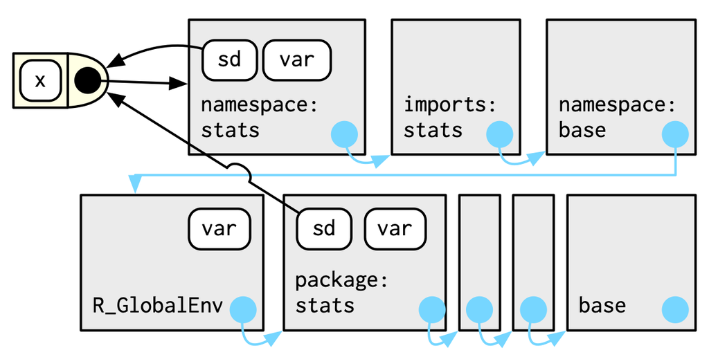

So when `sd()` looks for the value of `var` it always finds it in a sequence of environments determined by the package developer, but not by the package user. This ensures that package code always works the same way regardless of what packages have been attached by the user.

There’s no direct link between the package and namespace environments; the link is defined by the function environments.

### 7.4.4 Execution environments

The last important topic we need to cover is the **execution** environment. What will the following function return the first time it’s run? What about the second?

```r
g <- function(x) {
  if (!env_has(current_env(), "a")) {
    message("Defining a")
    a <- 1
  } else {
    a <- a + 1
  }
  a
}
```

Think about it for a moment before you read on.

```r
g(10)
```

```
## Defining a
```

```
## [1] 1
```

```r
g(10)
```

```
## Defining a
```

```
## [1] 1
```

```r
h <- function(x) {
  # 1.
  a <- 2 # 2.
  x + a
}
y <- h(1) # 3.
```

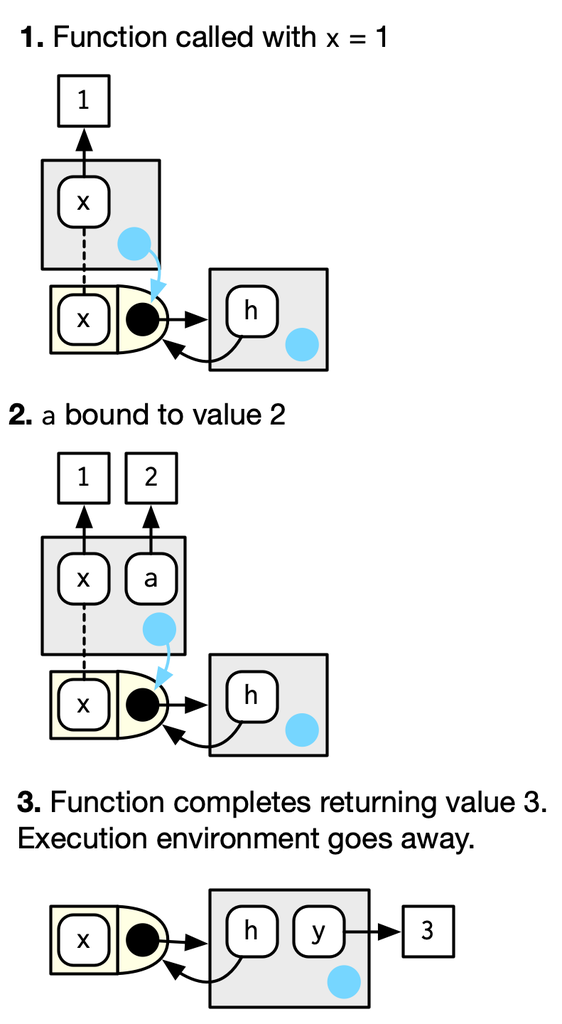

The execution environment of a simple function call. Note that the parent of the execution environment is the function environment.

An execution environment is usually ephemeral; once the function has completed, the environment will be garbage collected. There are several ways to make it stay around for longer. The first is to explicitly return it:

```r
h2 <- function(x) {
  a <- x * 2
  current_env()
}

e <- h2(x = 10)
env_print(e)
```

```
## <environment: 0x000002044d659c70>
## Parent: <environment: global>
## Bindings:
## • a: <dbl>
## • x: <dbl>
```

```r
fn_env(h2)
```

```
## <environment: R_GlobalEnv>
```

Another way to capture it is to return an object with a binding to that environment, like a function. The following example illustrates that idea with a function factory, `plus()`. We use that factory to create a function called `plus_one()`.

There’s a lot going on in the diagram because the enclosing environment of `plus_one()` is the execution environment of `plus()`.

```r
plus <- function(x) {
  function(y) x + y
}

plus_one <- plus(1)
plus_one
```

```
## function(y) x + y
## <environment: 0x00000204500f3b38>
```

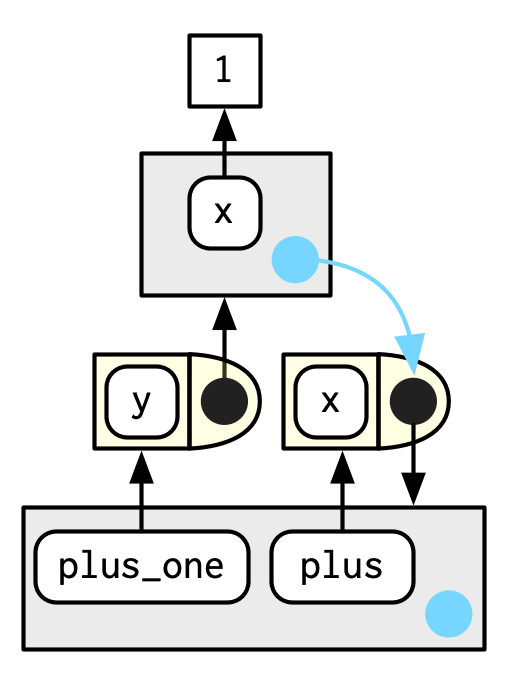

What happens when we call `plus_one()`? Its execution environment will have the captured execution environment of `plus()` as its parent:

```r
plus_one(2)
```

```
## [1] 3
```

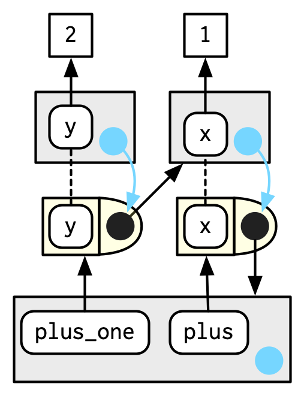

You’ll learn more about function factories in Section @ref(factory-fundamentals).

### 7.4.5 Exercises

1. How is `search_envs()` different from `env_parents(global_env())`?

```r
search_envs()
```

```
##  [[1]] $ <env: global>
##  [[2]] $ <env: package:rlang>
##  [[3]] $ <env: package:stats>
##  [[4]] $ <env: package:graphics>
##  [[5]] $ <env: package:grDevices>
##  [[6]] $ <env: package:utils>
##  [[7]] $ <env: package:datasets>
##  [[8]] $ <env: package:methods>
##  [[9]] $ <env: Autoloads>
## [[10]] $ <env: package:base>
```

> search_envs() returns the environments on the search path as a list, which is “a chain of environments containing exported functions of attached packages”.

> Every time you attach a new package, this search path will grow. The search path ends with the base-environment. The global environment is included, because functions present in the global environment will always be part of the search path.

```r
env_parents(global_env())
```

```
##  [[1]] $ <env: package:rlang>
##  [[2]] $ <env: package:stats>
##  [[3]] $ <env: package:graphics>
##  [[4]] $ <env: package:grDevices>
##  [[5]] $ <env: package:utils>
##  [[6]] $ <env: package:datasets>
##  [[7]] $ <env: package:methods>
##  [[8]] $ <env: Autoloads>
##  [[9]] $ <env: package:base>
## [[10]] $ <env: empty>
```

> env_parents() returns the list of all parents, including the empty environment.

> env_parents(global_env()) will list all the ancestors of the global environment, therefore the global environment itself is not included. This also includes the “ultimate ancestor,” the empty environment. This environment is not considered part of the search path because it contains no objects.
2. Draw a diagram that shows the enclosing environments of this function:

   ```r
   f1 <- function(x1) {
     f2 <- function(x2) {
       f3 <- function(x3) {
         x1 + x2 + x3
       }
       f3(3)
     }
     f2(2)
   }
   f1(1)
   ```

> We can also inspect the binding of the environments, adding print statements to the function definition. Please note that these print statements will be evaluated at execution time. Therefore, the execution of f1(1) will print different results each time we run it.

```r
    f1 <- function(x1) {
      f2 <- function(x2) {
        f3 <- function(x3) {
          x1 + x2 + x3
        }
        f3(3)
        env_print()
      }
      f2(2)
      env_print()
    }
    f1(1)
```

```
## <environment: 0x0000020450d28bb8>
## Parent: <environment: 0x0000020450d28d78>
## Bindings:
## • f3: <fn>
## • x2: <dbl>
## <environment: 0x0000020450d28d78>
## Parent: <environment: global>
## Bindings:
## • f2: <fn>
## • x1: <dbl>
```

```r
    env_print()
```

```
## <environment: global>
## Parent: <environment: package:rlang>
## Bindings:
## • plus_one: <fn>
## • h2: <fn>
## • y: <dbl>
## • e: <env>
## • f: <fn>
## • g: <fn>
## • h: <fn>
## • plus: <fn>
## • f1: <fn>
```

> When f1 is defined it binds its parent environment, which is the global environment. But f2 will only be created at runtime of f1 and will therefore bind f1’s execution environment. The value 1 will also bind to the name x1 at execution time. The same holds true for x2, f3 and x3.

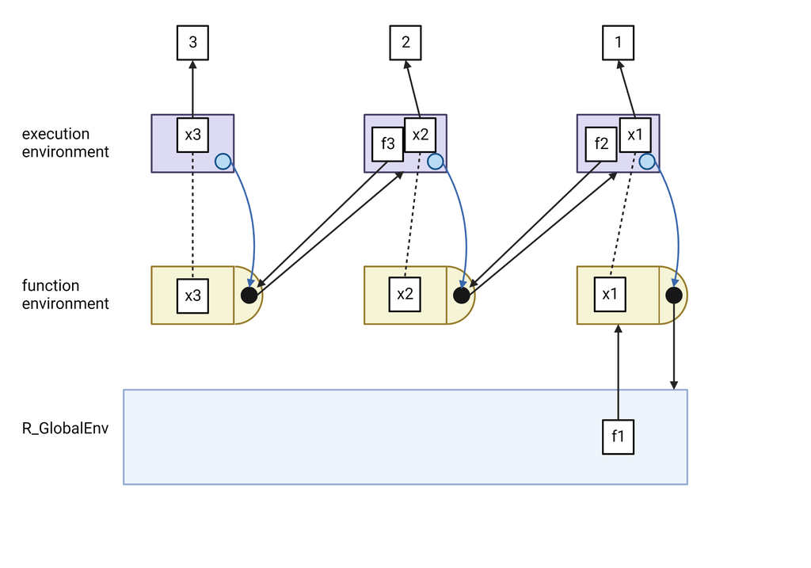

3. Write an enhanced version of `str()` that provides more information about functions. Show where the function was found and what environment it was defined in.

```r
#?str
```

> To solve this problem, we need to write a function that takes the name of a function and looks for that function returning both the function and the environment that it was found in.

```r
fget <- function(name, env = caller_env()) {

  # Base case
  if (identical(env, emptyenv())) {
    stop("Could not find a function called ", name, ".", call. = FALSE)
    }

  # Success case
  else{
    if (env_has(env, name)) {
      obj <- env_get(env, name)
      if (is.function(obj)) {
        return(list(fun = obj, env = env))
      }
    }
  }

  # Recursive anyway
  fget(name, env_parent(env))
}
```

```r
fstr <- function(fun_name, env = caller_env()) {
  if (!is.character(fun_name)) {
    stop("`fun_name` should be a string.", call. = FALSE)
  }
  fun_env <- fget(fun_name, env)

  list(
    environment = fun_env$env,
    namespace = fn_env(fun_env$fun)
  )
}
```

```r
# Test
fstr("mean")
```

```
## $environment
## <environment: base>
##
## $namespace
## <environment: namespace:base>
```

```r
fstr("str")
```

```
## $environment
## <environment: package:utils>
## attr(,"name")
## [1] "package:utils"
## attr(,"path")
## [1] "C:/Users/myj23/AppData/Local/Programs/R/R-4.2.2/library/utils"
##
## $namespace
## <environment: namespace:utils>
```

## 7.5 Call stacks

There is one last environment we need to explain, the **caller** environment, accessed with `rlang::caller_env()`. This provides the environment from which the function was called, and hence varies based on how the function is called, not how the function was created. As we saw above this is a useful default whenever you write a function that takes an environment as an argument.

`parent.frame()` is equivalent to `caller_env()`; just note that it returns an environment, not a frame.

To fully understand the caller environment we need to discuss two related concepts: the **call stack**, which is made up of **frames**. Executing a function creates two types of context. You’ve learned about one already: the execution environment is a child of the function environment, which is determined by where the function was created. There’s another type of context created by where the function was called: this is called the call stack.

### 7.5.1 Simple call stacks

Let’s illustrate this with a simple sequence of calls: `f()` calls `g()` calls `h()`.

```r
# f calls g, which calls h, which calls stop.
# When an error is thrown, R stops executing the current function
# and goes back to the function that called it.
f <- function(x) {
  g(x = 2)
}
g <- function(x) {
  h(x = 3)
}
h <- function(x) {
  stop()
}
```

The way you most commonly see a call stack in R is by looking at the `traceback()` after an error has occurred:

```r
f(x = 1)
```

```
#> Error:
```

```r
traceback()
```

```
#> 4: stop()
#> 3: h(x = 3)
#> 2: g(x = 2)
#> 1: f(x = 1)
```

Instead of `stop()` + `traceback()` to understand the call stack, we’re going to use `lobstr::cst()` to print out the **c**all **s**tack **t**ree:

```r
h <- function(x) {
  lobstr::cst()
}
f(x = 1)
```

```
#> █
#> └─f(x = 1)
#>   └─g(x = 2)
#>     └─h(x = 3)
#>       └─lobstr::cst()
```

This shows us that `cst()` was called from `h()`, which was called from `g()`, which was called from `f()`. Note that the order is the opposite from `traceback()`. As the call stacks get more complicated, I think it’s easier to understand the sequence of calls if you start from the beginning, rather than the end (i.e. `f()` calls `g()`; rather than `g()` was called by `f()`).

### 7.5.2 Lazy evaluation

The call stack above is simple: while you get a hint that there’s some tree-like structure involved, everything happens on a single branch. This is typical of a call stack when all arguments are eagerly evaluated.

Let’s create a more complicated example that involves some lazy evaluation. We’ll create a sequence of functions, `a()`, `b()`, `c()`, that pass along an argument `x`.

```r
# a is a function that takes an argument x and calls b(x)
a <- function(x) b(x)

# b is a function that takes an argument x and calls c(x)
b <- function(x) c(x)

# c is a function that takes an argument x and returns x
c <- function(x) x

# The function a is called with the result of calling f.
a(f())
```

```
#> █
#> ├─a(f())
#> │ └─b(x)
#> │   └─c(x)
#> └─f()
#>   └─g(x = 2)
#>     └─h(x = 3)
#>       └─lobstr::cst()
```

`x` is lazily evaluated so this tree gets two branches. In the first branch `a()` calls `b()`, then `b()` calls `c()`. The second branch starts when `c()` evaluates its argument `x`. This argument is evaluated in a new branch because the environment in which it is evaluated is the global environment, not the environment of `c()`.

### 7.5.3 Frames

Each element of the call stack is a **frame**[^2], also known as an evaluation context. The frame is an extremely important internal data structure, and R code can only access a small part of the data structure because tampering with it will break R. A frame has three key components:

- An expression (labelled with `expr`) giving the function call. This is what `traceback()` prints out.
- An environment (labelled with `env`), which is typically the execution environment of a function. There are two main exceptions: the environment of the global frame is the global environment, and calling `eval()` also generates frames, where the environment can be anything.
- A parent, the previous call in the call stack (shown by a grey arrow).

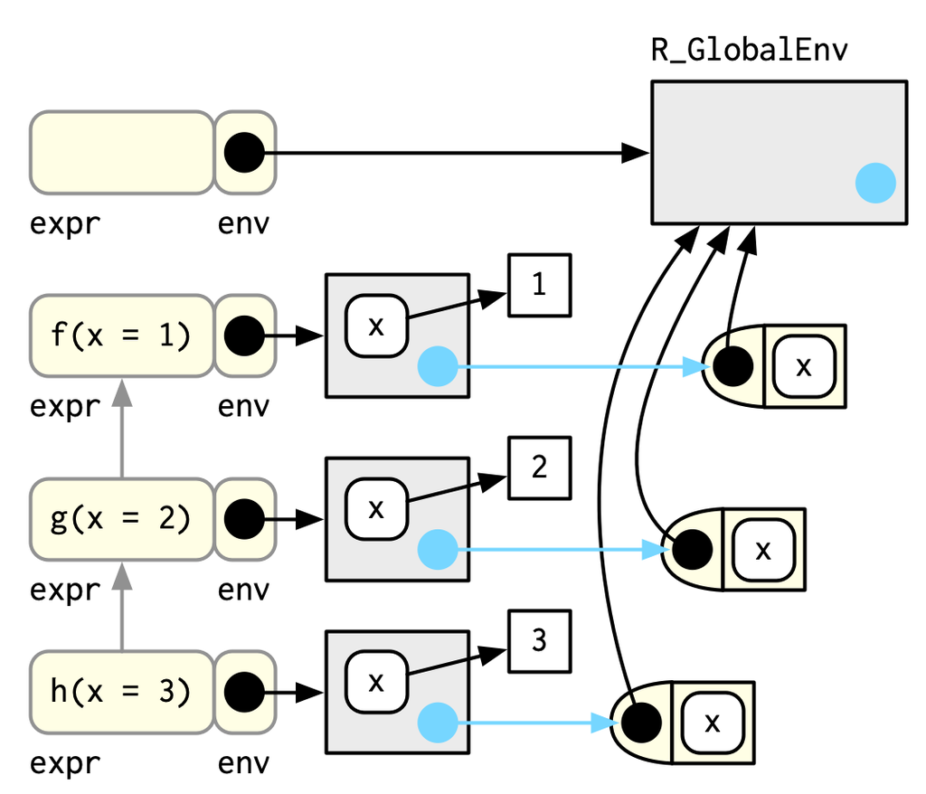

The graphical depiction of a simple call stack

(To focus on the calling environments, I have omitted the bindings in the global environment from `f`, `g`, and `h` to the respective function objects.)

The frame also holds exit handlers created with `on.exit()`, restarts and handlers for the condition system, and which context to `return()` to when a function completes. These are important internal details that are not accessible with R code.

### 7.5.4 Dynamic scope

Looking up variables in the calling stack rather than in the enclosing environment is called **dynamic scoping**. Few languages implement dynamic scoping (Emacs Lisp is a [notable exception](http://www.gnu.org/software/emacs/emacs-paper.html#SEC15).) This is because dynamic scoping makes it much harder to reason about how a function operates: not only do you need to know how it was defined, you also need to know the context in which it was called. Dynamic scoping is primarily useful for developing functions that aid interactive data analysis, and one of the topics discussed in Chapter @ref(evaluation).

### 7.5.5 Exercises

1. Write a function that lists all the variables defined in the environment in which it was called. It should return the same results as `ls()`.

> ls shows what data sets and functions a user has defined.

```r
ls
```

```
## function (name, pos = -1L, envir = as.environment(pos), all.names = FALSE,
##     pattern, sorted = TRUE)
## {
##     if (!missing(name)) {
##         pos <- tryCatch(name, error = function(e) e)
##         if (inherits(pos, "error")) {
##             name <- substitute(name)
##             if (!is.character(name))
##                 name <- deparse(name)
##             warning(gettextf("%s converted to character string",
##                 sQuote(name)), domain = NA)
##             pos <- name
##         }
##     }
##     all.names <- .Internal(ls(envir, all.names, sorted))
##     if (!missing(pattern)) {
##         if ((ll <- length(grep("[", pattern, fixed = TRUE))) &&
##             ll != length(grep("]", pattern, fixed = TRUE))) {
##             if (pattern == "[") {
##                 pattern <- "\\["
##                 warning("replaced regular expression pattern '[' by  '\\\\['")
##             }
##             else if (length(grep("[^\\\\]\\[<-", pattern))) {
##                 pattern <- sub("\\[<-", "\\\\\\[<-", pattern)
##                 warning("replaced '[<-' by '\\\\[<-' in regular expression pattern")
##             }
##         }
##         grep(pattern, all.names, value = TRUE)
##     }
##     else all.names
## }
## <bytecode: 0x000002044c8dcb00>
## <environment: namespace:base>
```

```r
function (name, pos = -1L, envir = as.environment(pos), all.names = FALSE,
  pattern, sorted = TRUE)
{
  # If the name argument is not missing,
  # then it is converted to a character string.
  if (!missing(name)) {
    pos <- tryCatch(name, error = function(e) e)
    if (inherits(pos, "error")) {
      name <- substitute(name)
      if (!is.character(name))
        name <- deparse(name)
      warning(gettextf("%s converted to character string",
        sQuote(name)), domain = NA)
      pos <- name
    }
  }

  # .Internal() function is called with the envir argument
  # set to the global environment.
  all.names <- .Internal(ls(envir, all.names, sorted))
  # The all.names argument is set to the result of
  # the .Internal() function call.

  # If the pattern argument is not missing,
  # then the grep() function is called with the pattern and all.names arguments.
  if (!missing(pattern)) {
    if ((ll <- length(grep("[", pattern, fixed = TRUE))) &&
      ll != length(grep("]", pattern, fixed = TRUE))) {
      if (pattern == "[") {
        pattern <- "\\["
        warning("replaced regular expression pattern '[' by  '\\\\['")
      }
      else if (length(grep("[^\\\\]\\[<-", pattern))) {
        pattern <- sub("\\[<-", "\\\\\\[<-", pattern)
        warning("replaced '[<-' by '\\\\[<-' in regular expression pattern")
      }
    }

    # The result of the grep() function call is returned.
    grep(pattern, all.names, value = TRUE)
  }

  # If the pattern argument is missing, then all.names is returned.
  else all.names
}
```

```r
ls()
```

```
##  [1] "e"        "f"        "f1"       "fget"     "fstr"     "g"
##  [7] "h"        "h2"       "plus"     "plus_one" "y"
```

```r
env_names(current_env())
```

```
##  [1] "plus_one" "h2"       "y"        "e"        "f"        "g"
##  [7] "fget"     "h"        "fstr"     "plus"     "f1"
```

> We can implement this dynamic scoping behaviour by explicitly referencing the caller environment. Please note that this approach returns also variables starting with a dot, an option that ls() usually requires.

```r
new_ls <- function(env = caller_env()) {
  sort(env_names(env))
}
```

```r
ls(all.names = TRUE)
```

```
##  [1] "e"        "f"        "f1"       "fget"     "fstr"     "g"
##  [7] "h"        "h2"       "new_ls"   "plus"     "plus_one" "y"
```

```r
new_ls()
```

```
##  [1] "e"        "f"        "f1"       "fget"     "fstr"     "g"
##  [7] "h"        "h2"       "new_ls"   "plus"     "plus_one" "y"
```

```r
#test
ls(e)
```

```
## [1] "a" "x"
```

```r
new_ls(e)
```

```
## [1] "a" "x"
```

## 7.6 As data structures

As well as powering scoping, environments are also useful data structures in their own right because they have reference semantics. There are three common problems that they can help solve:

- **Avoiding copies of large data**. Since environments have reference semantics, you’ll never accidentally create a copy. But bare environments are painful to work with, so instead I recommend using R6 objects, which are built on top of environments. Learn more in Chapter @ref(r6).
- **Managing state within a package**. Explicit environments are useful in packages because they allow you to maintain state across function calls. Normally, objects in a package are locked, so you can’t modify them directly. Instead, you can do something like this:

  ```r
  # Create a new environment called my_env.
  my_env <- new.env(parent = emptyenv())

  # Set the value of a in my_env to 1.
  my_env$a <- 1

  # Create a function called get_a that returns the value of a in my_env.
  get_a <- function() {
    my_env$a
  }

  # Create a function called set_a
  # that sets the value of a in my_env to the value passed to the function.
  set_a <- function(value) {
    old <- my_env$a
    my_env$a <- value
    invisible(old)
  }
  ```

  Returning the old value from setter functions is a good pattern because it makes it easier to reset the previous value in conjunction with `on.exit()` (Section @ref(on-exit)).
- **As a hashmap**. A hashmap is a data structure that takes constant, O(1), time to find an object based on its name. Environments provide this behaviour by default, so can be used to simulate a hashmap. See the hash package [@hash] for a complete development of this idea.
[^1]: Note the difference between attached and loaded. A package is loaded automatically if you access one of its functions using `::`; it is only **attached** to the search path by `library()` or `require()`.
[^2]: NB: `?environment` uses frame in a different sense: “Environments consist of a *frame*, or collection of named objects, and a pointer to an enclosing environment.” We avoid this sense of frame, which comes from S, because it’s very specific and not widely used in base R. For example, the frame in `parent.frame()` is an execution context, not a collection of named objects.